# trupol US data

Erica Yoon

August 29, 2015

```r
# trupol_ana_preprocess

rm(list=ls())
library(ggplot2)
library(plyr)
library(dplyr)
library(tidyr)
source("/Users/ericang/Documents/Research/Politeness/trupol_git/data_analysis/helper/useful.R")
d <- read.csv("/Users/ericang/Documents/Research/Politeness/trupol_git/data_analysis/data/trupol_data.csv")
log <- read.csv("/Users/ericang/Documents/Research/Politeness/trupol_git/data_analysis/info/trupol_subj.csv")

# join with subj log
d <- join(d, log)
# select key vars
d <- d %>%
  select(subid, Age, site, trial1_2_evalCorrect, trial1_2_playCorrect, trial3_4_playCorrect, trial3_4_evalCorrect, trial1_niceness, trial2_niceness, trial3_niceness, trial4_niceness, trial1_Lfeel_val, trial2_Lfeel_val, trial3_Lfeel_val, trial4_Lfeel_val)

# categorize age
d$Age <- as.numeric(as.character(d$Age))
d <- cbind(d, age_cat = cut(d$Age, breaks=c(3, 4, 5, 6, 7)))
levels(d$age_cat) <- c("3", "4", "5", "6")
summary(d$age_cat)
```

```
##    3    4    5    6 NA's
##    5   18   19   11    4
```

```r
# reshape data
d <- d %>%
  gather("q", "answer", 4:15)
# add columns to categorize vars
d1 <- d %>%
  mutate(polite = factor(substring(q, 1, 8),
                         levels = c("trial1_2", "trial3_4",
                                    "trial1_n", "trial2_n", "trial3_n", "trial4_n",
                                    "trial1_L", "trial2_L", "trial3_L", "trial4_L"),
                         labels = c("NA", "NA",
                                    "impolite", "polite", "polite", "impolite",
                                    "impolite", "polite", "polite", "impolite")),
         q_kind = factor(substring(q, 8, 10),
                         levels = c("2_e", "2_p", "4_p", "4_e",
                                    "nic", "Lfe"),
                         labels = c("eval", "play", "play", "eval",
                                    "niceness", "Lfeel")))
d1$polite <- as.factor(as.character(d1$polite))
d1$q_kind <- as.factor(as.character(d1$q_kind))
d1$answer <- as.factor(as.character(d1$answer))
levels(d1$answer) <- c("NA", "NA", "0", "NA", "1", "2", "3", "4", "5", "0", "1")
d1$answer <- as.numeric(as.character(d1$answer))
```

# correct responses on eval and play questions

play: “who do you want to play with?” eval: “whose snack do you think is tastier (given the same utterance)?”

```r
# plot: eval and play
mss <- d1 %>%
  filter(q_kind == "play" | q_kind == "eval") %>%
  group_by(q_kind, age_cat, site, subid) %>%
  summarize(
    answer = mean(answer, na.rm=TRUE)
  )
ms <- aggregate(answer ~ q_kind + age_cat + site, mss, mean)
ms$cih <- aggregate(answer ~ q_kind + age_cat + site, mss, ci.high)$answer
ms$cil <- aggregate(answer ~ q_kind + age_cat + site, mss, ci.low)$answer
```

## barplot:

x-axis: age groups y-axis: answer; 0 = incorrect, 1 = correct

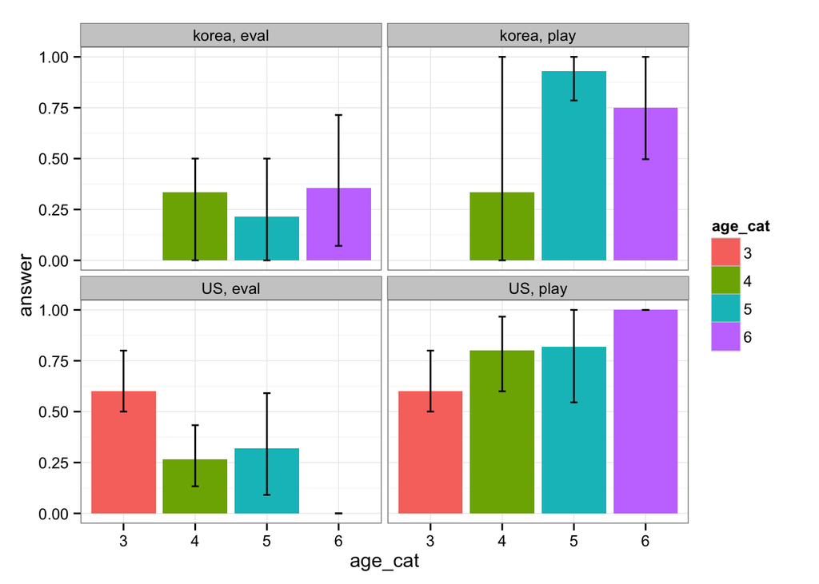

```r
qplot(age_cat, answer,
      fill = age_cat,
      geom="bar", position = "dodge", stat="identity",
      data=subset(ms, answer!="NA")) +
  facet_wrap(site~q_kind) +
  geom_errorbar(aes(ymin=answer-cil,ymax=answer+cih,width=.1))
```

- more correct on play than eval overall
- older group performs better overall (?)

## histogram:

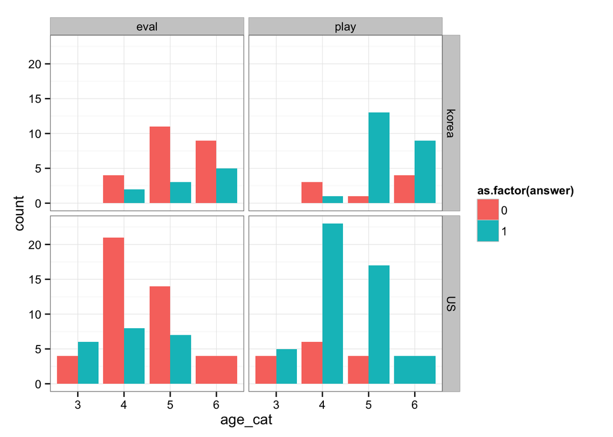

```r
# histogram
qplot(age_cat, # 1 = correct
      fill = as.factor(answer), position = "dodge",
      geom="histogram",
      data=subset(d1, answer!="NA" & (q_kind == "play" | q_kind == "eval"))) +
      facet_grid(site~q_kind)
```

- korea and US show opposite pattern for eval? in Korea, older groups answer more correctly on eval, whereas in US, they answer more INcorrectly (i.e., given the same positive utterance from both the nice person and mean person, they say nicer person’s stuff is better)

# niceness rating

“How nice is he/she?”

```r
# plot: niceness
mss <- d1 %>%
  filter(q_kind == "niceness") %>%
  group_by(polite, age_cat, site, subid) %>%
  summarize(
    answer = mean(answer, na.rm=TRUE)
  )
ms <- aggregate(answer ~ polite + age_cat + site, mss, mean)
ms$cih <- aggregate(answer ~ polite + age_cat + site, mss, ci.high)$answer
ms$cil <- aggregate(answer ~ polite + age_cat + site, mss, ci.low)$answer
```

## barplot

1 = really mean, 5 = really nice

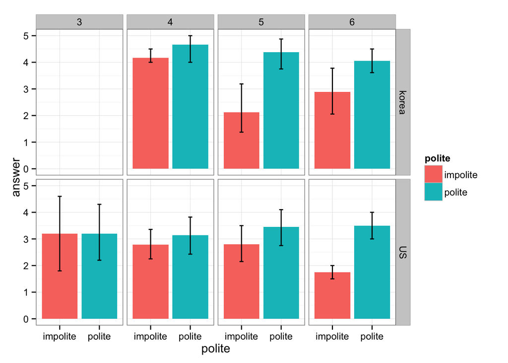

```r
qplot(polite, answer,
      fill = polite,
      geom="bar", position = "dodge", stat="identity",
      data=subset(ms, answer!="NA")) +
  facet_grid(site~age_cat) +
  geom_errorbar(aes(ymin=answer-cil,ymax=answer+cih,width=.1))
```

The older group performs better: they correctly infer that the polite speaker is nicer

## histogram

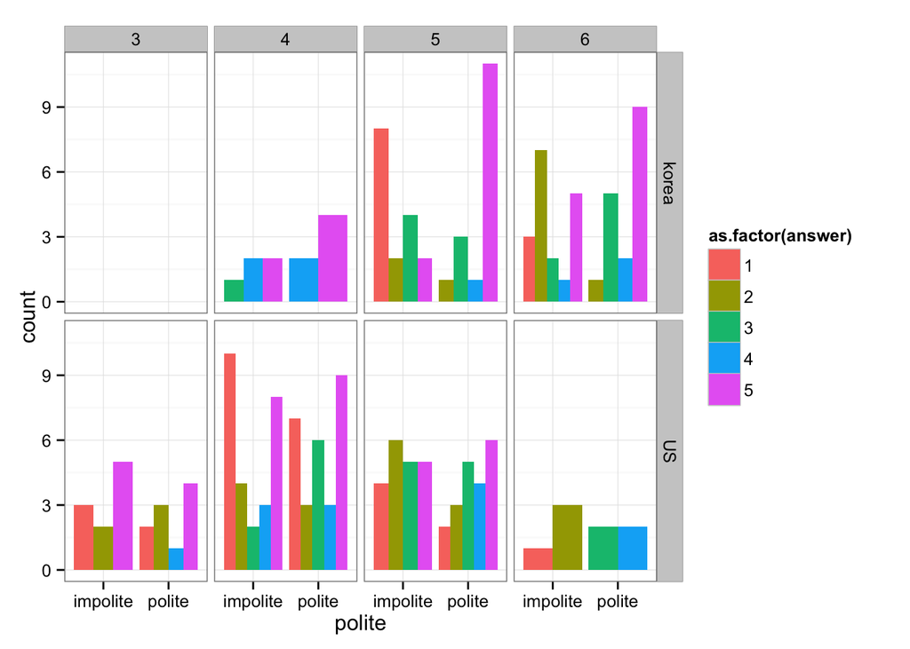

```r
# histogram
qplot(polite,
      fill = as.factor(answer),
      geom="histogram", position = "dodge",
      data=subset(d1, answer!="NA" & (q_kind == "niceness") & site != "NA")) +
      facet_grid(site~age_cat)
```

# listener’s feeling

“How did he/she feel (after hearing the speaker’s utterance)?”

```r
# plot: listener feeling inference
mss <- d1 %>%
  filter(q_kind == "Lfeel") %>%
  group_by(polite, age_cat, site, subid) %>%
  summarize(
    answer = mean(answer, na.rm=TRUE)
  )

# look at correctness of responses
mss[mss$polite == "impolite",]$answer <- (mss[mss$polite == "impolite",]$answer - 1) * (-1)

ms <- aggregate(answer ~ polite + age_cat + site, mss, mean)
ms$cih <- aggregate(answer ~ polite + age_cat + site, mss, ci.high)$answer
ms$cil <- aggregate(answer ~ polite + age_cat + site, mss, ci.low)$answer
```

## barplot

0 = incorrect, 1 = correct

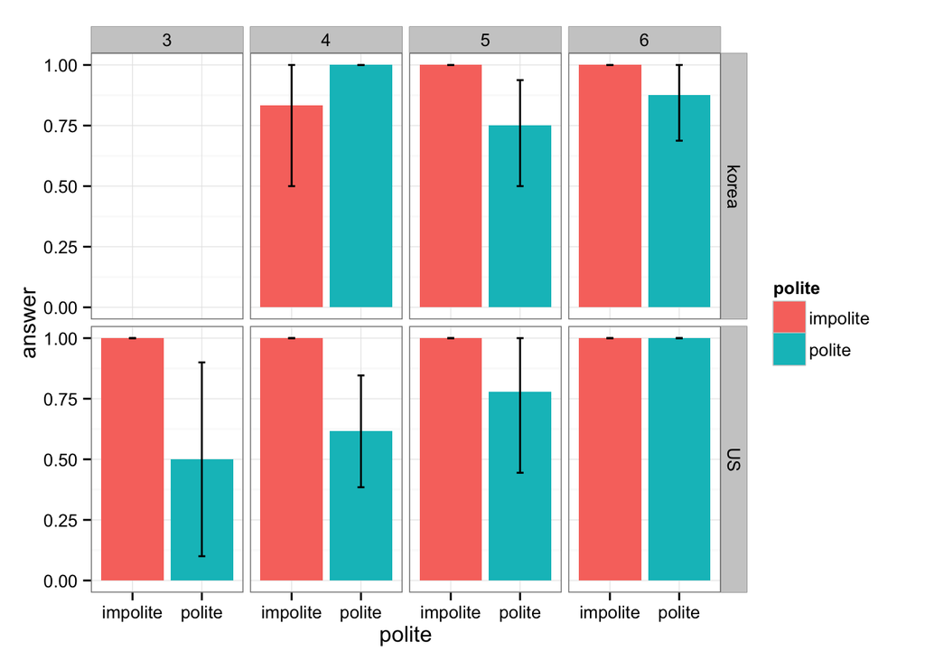

```r
qplot(polite, answer,
      fill = polite,
      geom="bar", position = "dodge", stat="identity",
      data=subset(ms, answer!="NA")) +
  facet_grid(site~age_cat) +
  geom_errorbar(aes(ymin=answer-cil,ymax=answer+cih,width=.1))
```

For both sites, 5-6 year-olds all correctly infer the listener’s feeling after hearing the impolite speaker’s utterance (“they felt bad”), whereas more errors occur for listener’s feeling upon hearing the polite speaker’s utterance.

Weird pattern for 3-4 year-olds: because of too small number? - probably, look at the histogram below

## histogram

0 = incorrect, 1 = correct

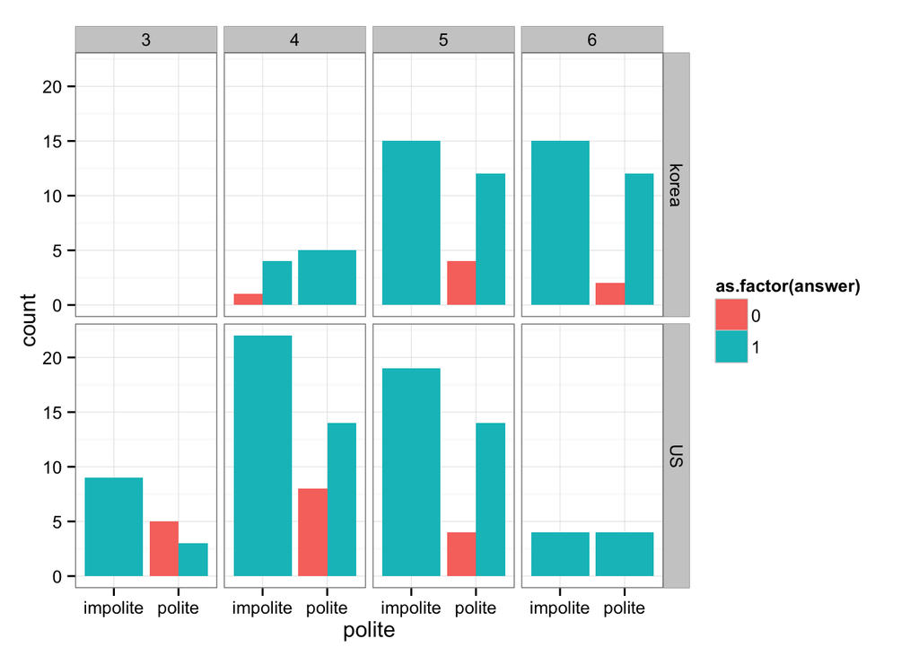

```r
# histogram
# temporary data d2
d2 <- d1
# look at correctness of responses
d2$answer <- as.numeric(as.character(d2$answer))
d2[d2$polite == "impolite",]$answer <- (d2[d2$polite == "impolite",]$answer - 1) * (-1)

qplot(polite,
      fill = as.factor(answer),
      geom="histogram", position = "dodge",
      data=subset(d2, answer!="NA" & (q_kind == "Lfeel") & site != "NA")) +
      facet_grid(site~age_cat)
```

Pattern looks the same for Korea and US

# niceness x listener’s feeling

For participants who correctly inferred listener’s feeling upon hearing the utterance, did they infer the speaker’s niceness better too?

```r
d <- read.csv("/Users/ericang/Documents/Research/Politeness/trupol_git/data_analysis/data/trupol_data.csv")
log <- read.csv("/Users/ericang/Documents/Research/Politeness/trupol_git/data_analysis/info/trupol_subj.csv")

# join with subj log
d <- join(d, log)
# select key vars
d <- d %>%
  select(subid, Age, site, trial1_niceness, trial2_niceness, trial3_niceness, trial4_niceness, trial1_Lfeel_val, trial2_Lfeel_val, trial3_Lfeel_val, trial4_Lfeel_val)

# categorize age
d$Age <- as.numeric(as.character(d$Age))
d <- cbind(d, age_cat = cut(d$Age, breaks=c(3, 4, 5, 6, 7)))
levels(d$age_cat) <- c("3", "4", "5", "6")

# reshape data
d <- d %>%
  gather("q", "answer", 4:11)
# add columns to categorize vars
d1 <- d %>%
  mutate(trial = substring(q, 6, 6), q_kind = substring(q, 8, 16)) %>%
  select(subid, site, age_cat, trial, q_kind, answer) %>%
  spread(q_kind, answer) %>%
  mutate(polite = factor(trial,
                         levels = c("1", "2", "3", "4"),
                         labels = c(
                                    "impolite", "polite", "polite", "impolite")))
d1$Lfeel_val <- as.factor(as.numeric(as.character(d1$Lfeel_val)))
d1$niceness <- as.numeric(as.character(d1$niceness))
d1$polite <- as.factor(as.character(d1$polite))
d1$site <- as.factor(as.character(d1$site))
```

## dotplot

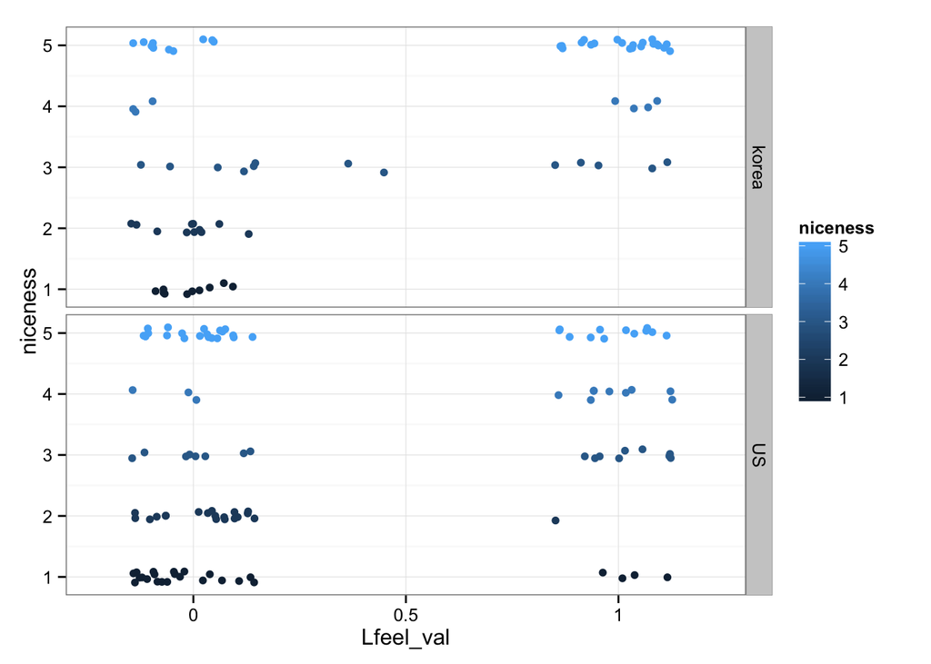

```r
ggplot(subset(d1, Lfeel_val != "NA" & site != "NA"), aes(x=Lfeel_val, y=niceness)) +
  geom_jitter(position = position_jitter(height = .1, width = .3), aes(colour = niceness)) +
  facet_grid(site~.)
```

Overall, those who thought the listener felt bad had more mixed responses about speaker’s niceness, whereas those who thought the listener felt good more correctly inferred the speaker was nice.

## dotplot: facetting by politeness

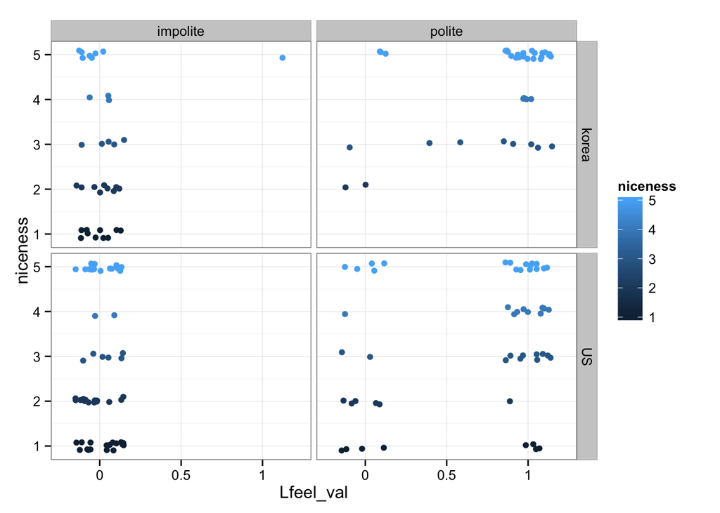

```r
# facet by politeness
ggplot(subset(d1, Lfeel_val != "NA" & site != "NA"), aes(x=Lfeel_val, y=niceness)) +
  geom_jitter(position = position_jitter(height = .1, width = .3), aes(colour = niceness)) +
  facet_grid(site~polite)
```